# STAT 434 Final Project

Jacob Oliver, Joe Hurtz

# Introduction

[output not shown]

# Exploratory, Descriptive Statistics and Graphics

```r
data <- read.table("/Users/Jake/Documents/STAT 434/Final Project/bank-full.csv", header = TRUE, sep = ";")
```

#### First let’s look at the first few rows of the data to get a sense of what it looks like.

```r
head(data)
```

```
##   age          job marital education default balance housing loan contact
## 1  58   management married  tertiary      no    2143     yes   no unknown
## 2  44   technician  single secondary      no      29     yes   no unknown
## 3  33 entrepreneur married secondary      no       2     yes  yes unknown
## 4  47  blue-collar married   unknown      no    1506     yes   no unknown
## 5  33      unknown  single   unknown      no       1      no   no unknown
## 6  35   management married  tertiary      no     231     yes   no unknown
##   day month duration campaign pdays previous poutcome  y
## 1   5   may      261        1    -1        0  unknown no
## 2   5   may      151        1    -1        0  unknown no
## 3   5   may       76        1    -1        0  unknown no
## 4   5   may       92        1    -1        0  unknown no
## 5   5   may      198        1    -1        0  unknown no
## 6   5   may      139        1    -1        0  unknown no
```

```r
require(ggplot2)
```

#### Next let’s look at some histograms of the variables so that we get an idea of how they’re distributed

```r
# THIS CODE IS COMMENTED OUT BECAUSE IT TAKES UP TOO MUCH SPACE
#for (val in names(data)) {
#  print(ggplot(data = data, aes_string(x = val)) + geom_histogram(stat="count"))
#}
```

#### Now let’s see how the explanatory variables are related to whether or not a person who was phoned actually opened a bank account

We’ll just look at the variables that are the most correlated with whether or not a person opens a bank account.

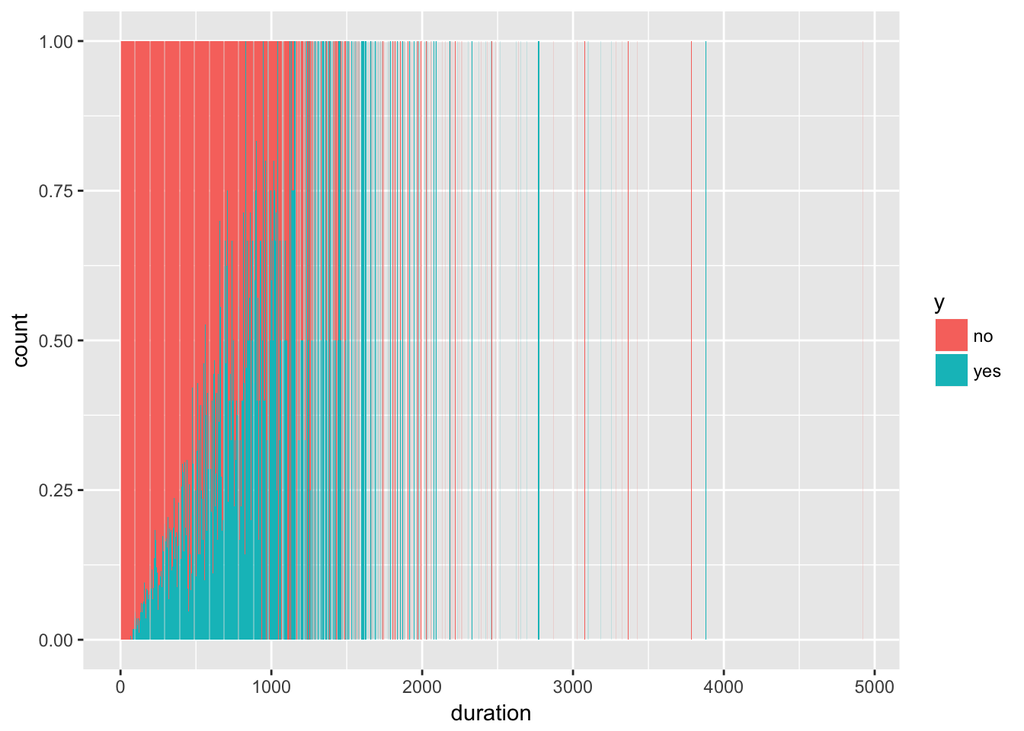

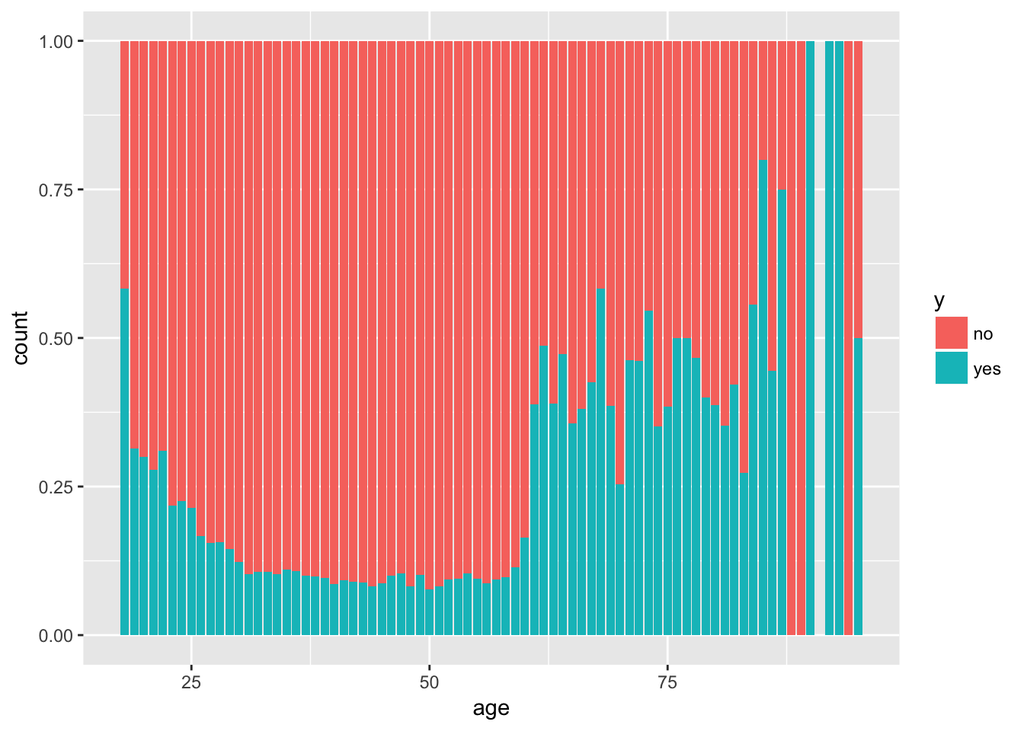

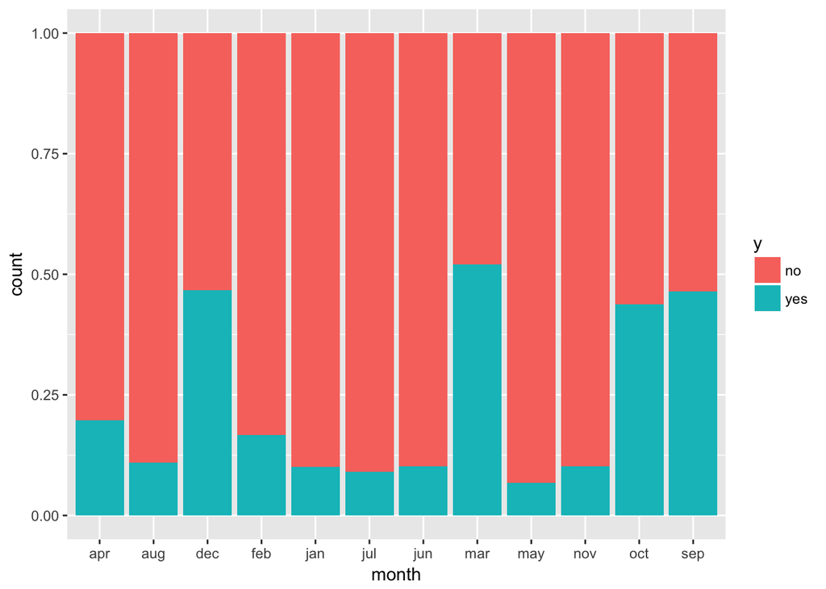

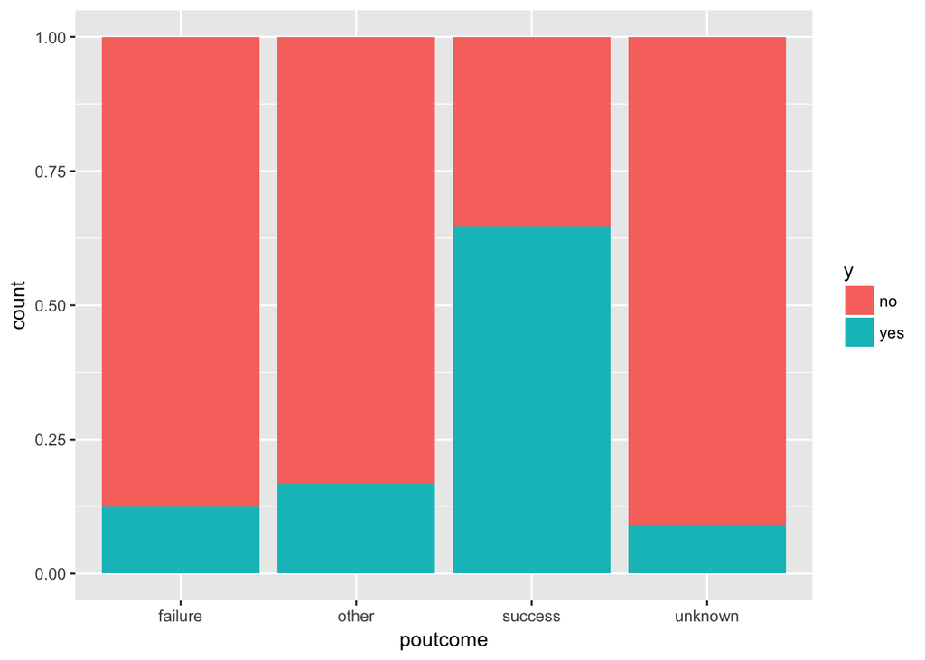

```r
for (val in c("duration", "age", "month", "poutcome")
     ) {
  print(ggplot(data = data, aes_string(x = val, fill = "y")) + geom_bar(position = "fill"))
}
```

It looks like the most important predictors are duration, month, age, and poutcome. #### Let’s look at how the quantitative variables interact with each other

```r
round(cor(cbind(data$age,data$balance,data$day,data$duration,data$campaign,data$pdays)), 2)
```

```
##       [,1]  [,2]  [,3]  [,4]  [,5]  [,6]
## [1,]  1.00  0.10 -0.01  0.00  0.00 -0.02
## [2,]  0.10  1.00  0.00  0.02 -0.01  0.00
## [3,] -0.01  0.00  1.00 -0.03  0.16 -0.09
## [4,]  0.00  0.02 -0.03  1.00 -0.08  0.00
## [5,]  0.00 -0.01  0.16 -0.08  1.00 -0.09
## [6,] -0.02  0.00 -0.09  0.00 -0.09  1.00
```

It looks like the quantitative variables aren’t very correlated. The largest correlation is 0.16 and the smallest correlation is -0.09.

# PCA

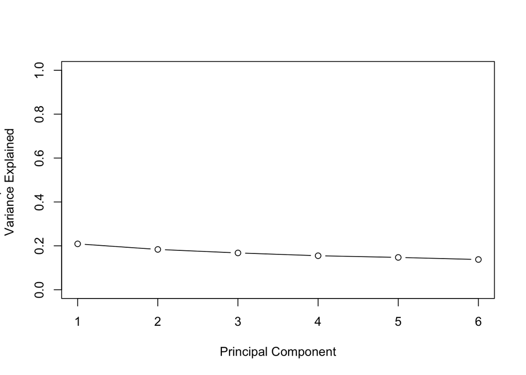

```r
pr.out <- prcomp(data[c("age","balance","day","duration","campaign","pdays")], scale = TRUE)
pr.var <- pr.out$sdev ^2
pve <- pr.var/sum(pr.var )
plot(pve , xlab=" Principal Component ", ylab=" Proportion of
Variance Explained ", ylim=c(0,1) ,type='b')
```

It doesn’t seem like we can use PCA to reduce the dimensionality of the data, because all of the principal components explain about the same variance.

# Classification Methods

```r
# We'll use 4 different sizes of training data: 10k, 20k, 30, and 40k
set.seed(1)
n <- nrow(data)
indices10k <- sample(1:n, 10000, replace = FALSE)
train10k <- data[indices10k,]
test10k <- data[-1*indices10k,]

set.seed(1)
n <- nrow(data)
indices20k <- sample(1:n, 20000, replace = FALSE)
train20k <- data[indices20k,]
test20k <- data[-1*indices20k,]

set.seed(1)
n <- nrow(data)
indices30k <- sample(1:n, 30000, replace = FALSE)
train30k <- data[indices30k,]
test30k <- data[-1*indices30k,]

set.seed(1)
n <- nrow(data)
indices40k <- sample(1:n, 40000, replace = FALSE)
train40k <- data[indices40k,]
test40k <- data[-1*indices40k,]
```

## Logistic Regression

```r
# 10k Training Size
glm.fits <- glm(y~., data = train10k, family = "binomial")
glm.pred <- ifelse(predict(glm.fits, test10k) > 0.5, "yes", "no")
1 - mean(glm.pred == test10k$y)
```

```
## [1] 0.1000824
```

```r
# 20k Training Size
glm.fits <- glm(y~., data = train20k, family = "binomial")
glm.pred <- ifelse(predict(glm.fits, test20k) > 0.5, "yes", "no")
1 - mean(glm.pred == test20k$y)
```

```
## [1] 0.09892507
```

```r
# 30k Training Size
glm.fits <- glm(y~., data = train30k, family = "binomial")
glm.pred <- ifelse(predict(glm.fits, test30k) > 0.5, "yes", "no")
1 - mean(glm.pred == test30k$y)
```

```
## [1] 0.09716652
```

```r
# 40k Training Size
glm.fits <- glm(y~., data = train40k, family = "binomial")
glm.pred <- ifelse(predict(glm.fits, test40k) > 0.5, "yes", "no")
1 - mean(glm.pred == test40k$y)
```

```
## [1] 0.0994051
```

## LDA

```r
require(MASS)
# 10k Training Size
lda.fit <- lda(y~., data = train10k)
lda.pred <- predict(lda.fit, test10k)$class
1 - mean(lda.pred == test10k$y)
```

```
## [1] 0.09883275
```

```r
# 20k Training Size
lda.fit <- lda(y~., data = train20k)
lda.pred <- predict(lda.fit, test20k)$class
1 - mean(lda.pred == test20k$y)
```

```
## [1] 0.09654516
```

```r
# 30k Training Size
lda.fit <- lda(y~., data = train30k)
lda.pred <- predict(lda.fit, test30k)$class
1 - mean(lda.pred == test30k$y)
```

```
## [1] 0.09644336
```

```r
# 40k Training Size
lda.fit <- lda(y~., data = train40k)
lda.pred <- predict(lda.fit, test40k)$class
1 - mean(lda.pred == test40k$y)
```

```
## [1] 0.09710228
```

## QDA

```r
# 10k Training Size
qda.fit <- qda(y~., data = train10k)
qda.pred <- predict(qda.fit, test10k)$class
1 - mean(qda.pred == test10k$y)
```

```
## [1] 0.1294766
```

```r
# 20k Training Size
qda.fit <- qda(y~., data = train20k)
qda.pred <- predict(qda.fit, test20k)$class
1 - mean(qda.pred == test20k$y)
```

```
## [1] 0.129507
```

```r
# 30k Training Size
qda.fit <- qda(y~., data = train30k)
qda.pred <- predict(qda.fit, test30k)$class
1 - mean(qda.pred == test30k$y)
```

```
## [1] 0.1263559
```

```r
# 40k Training Size
qda.fit <- qda(y~., data = train40k)
qda.pred <- predict(qda.fit, test40k)$class
1 - mean(qda.pred == test40k$y)
```

```
## [1] 0.1279985
```

## KNN

```r
require(class)
cv.knn <- function(trainData, ks) {
  train.X <- cbind(trainData$age,trainData$balance,trainData$day,trainData$duration,trainData$campaign,trainData$pdays)
  train.Y <- trainData$y
  cvMSE <- rep(NA, length(ks))
  set.seed(1)
  splits <- sample(1:nrow(trainData), replace = FALSE)
  cv.fold <- 10
  for (ix in 1:length(ks)) {
    cvErrors <- rep(NA, cv.fold)
    for (cvrep in 1:cv.fold) {
      splitsix <- splits[(cvrep*nrow(trainData)/cv.fold - (nrow(trainData)/cv.fold - 1)):(cvrep*nrow(trainData)/cv.fold)]
      trainSub <- trainData[-1*splitsix,]
      testSub <- trainData[splitsix,]
  #    print(nrow(trainSub))
  #    print(nrow(testSub))
      train.X <- cbind(trainSub$age,trainSub$balance,trainSub$day,trainSub$duration,trainSub$campaign,trainSub$pdays)
      train.Y <- trainSub$y
      test.X <- cbind(testSub$age,testSub$balance,testSub$day,testSub$duration,testSub$campaign,testSub$pdays)
      set.seed(1)
      pred <- knn(train.X, test.X, train.Y, k=ks[ix])
      cvErrors[cvrep] <- 1 -  mean((testSub$y == pred))
    }
    print(ix)
    cvMSE[ix] <- mean(cvErrors)
  }
  return(cvMSE)
}
```

```r
ks <- seq(4, 24, 2)
knn.10k <- cv.knn(train10k, ks)
```

```
## [1] 1
## [1] 2
## [1] 3
## [1] 4
## [1] 5
## [1] 6
## [1] 7
## [1] 8
## [1] 9
## [1] 10
## [1] 11
```

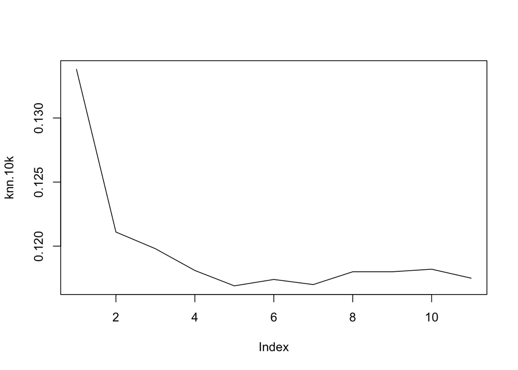

```r
plot(knn.10k, type = "l")
```

```r
knn.20k <- cv.knn(train20k, ks)
```

```
## [1] 1
## [1] 2
## [1] 3
## [1] 4
## [1] 5
## [1] 6
## [1] 7
## [1] 8
## [1] 9
## [1] 10
## [1] 11
```

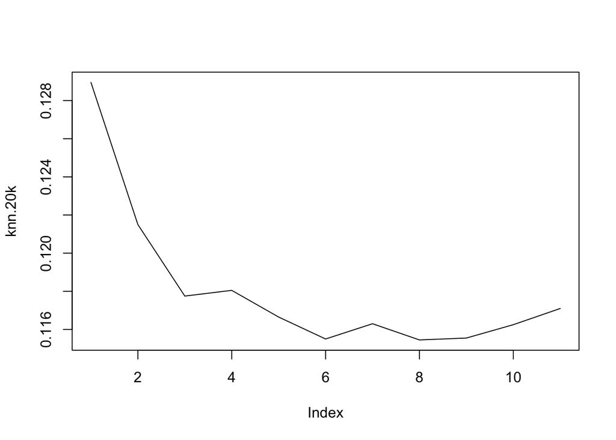

```r
plot(knn.20k, type = "l")
```

```r
knn.30k <- cv.knn(train30k, ks)
```

```
## [1] 1
## [1] 2
## [1] 3
## [1] 4
## [1] 5
## [1] 6
## [1] 7
## [1] 8
## [1] 9
## [1] 10
## [1] 11
```

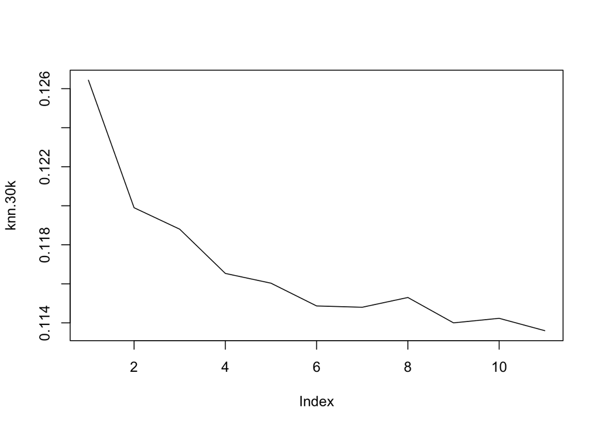

```r
plot(knn.30k, type = "l")
```

```r
knn.40k <- cv.knn(train40k, ks)
```

```
## [1] 1
## [1] 2
## [1] 3
## [1] 4
## [1] 5
## [1] 6
## [1] 7
## [1] 8
## [1] 9
## [1] 10
## [1] 11
```

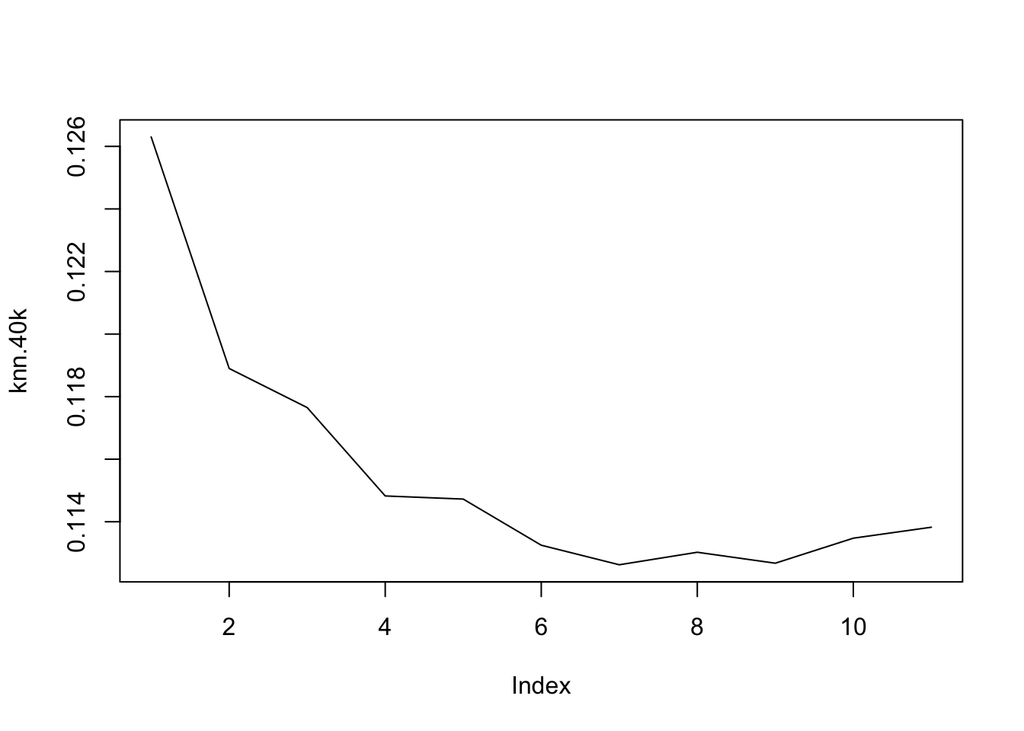

```r
plot(knn.40k, type = "l")
```

```r
c((which(min(knn.10k) == knn.10k) * 2) + 2,min(knn.10k));
```

```
## [1] 12.0000  0.1169
```

```r
c((which(min(knn.20k) == knn.20k) * 2) + 2,min(knn.20k));
```

```
## [1] 18.00000  0.11545
```

```r
c((which(min(knn.30k) == knn.30k) * 2) + 2,min(knn.30k));
```

```
## [1] 24.0000  0.1136
```

```r
c((which(min(knn.40k) == knn.40k) * 2) + 2,min(knn.40k));
```

```
## [1] 16.000000  0.112625
```

The lowest cross-validation error we get is for the 40k training set with k = 16.

#### Let’s find the test error for each training size where k = 16

```r
trainSub <- train10k
testSub <- test10k
train.X <- cbind(trainSub$age,trainSub$balance,trainSub$day,trainSub$duration,trainSub$campaign,trainSub$pdays)
train.Y <- trainSub$y
test.X <- cbind(testSub$age,testSub$balance,testSub$day,testSub$duration,testSub$campaign,testSub$pdays)
set.seed(1)
pred <- knn(train.X, test.X, train.Y, 16)
1 - mean((testSub$y == pred))
```

```
## [1] 0.1145097
```

```r
trainSub <- train20k
testSub <- test20k
train.X <- cbind(trainSub$age,trainSub$balance,trainSub$day,trainSub$duration,trainSub$campaign,trainSub$pdays)
train.Y <- trainSub$y
test.X <- cbind(testSub$age,testSub$balance,testSub$day,testSub$duration,testSub$campaign,testSub$pdays)
set.seed(1)
pred <- knn(train.X, test.X, train.Y, 16)
1 - mean((testSub$y == pred))
```

```
## [1] 0.1133235
```

```r
trainSub <- train30k
testSub <- test30k
train.X <- cbind(trainSub$age,trainSub$balance,trainSub$day,trainSub$duration,trainSub$campaign,trainSub$pdays)
train.Y <- trainSub$y
test.X <- cbind(testSub$age,testSub$balance,testSub$day,testSub$duration,testSub$campaign,testSub$pdays)
set.seed(1)
pred <- knn(train.X, test.X, train.Y, 16)
1 - mean((testSub$y == pred))
```

```
## [1] 0.1109066
```

```r
trainSub <- train40k
testSub <- test40k
train.X <- cbind(trainSub$age,trainSub$balance,trainSub$day,trainSub$duration,trainSub$campaign,trainSub$pdays)
train.Y <- trainSub$y
test.X <- cbind(testSub$age,testSub$balance,testSub$day,testSub$duration,testSub$campaign,testSub$pdays)
set.seed(1)
pred <- knn(train.X, test.X, train.Y, 16)
1 - mean((testSub$y == pred))
```

```
## [1] 0.1101516
```

## Classification Trees

```r
library(tree)

# 10k Training Size
set.seed(1)
train <- sample(1:nrow(data), size = 10000)
data.train <- data[train,]
data.test <- data[-train,]

# Create initial tree
tree.data <- tree(factor(y)~., data.train)

# Analyze test error
preds <- predict(tree.data, newdata = data.test, type = "class")
conf.mat <- table(preds, data.test$y)
conf.mat
```

```
##
## preds    no   yes
##   no  30437  3182
##   yes   689   903
```

```r
sum(preds != data.test$y)/length(preds)
```

```
## [1] 0.1099372
```

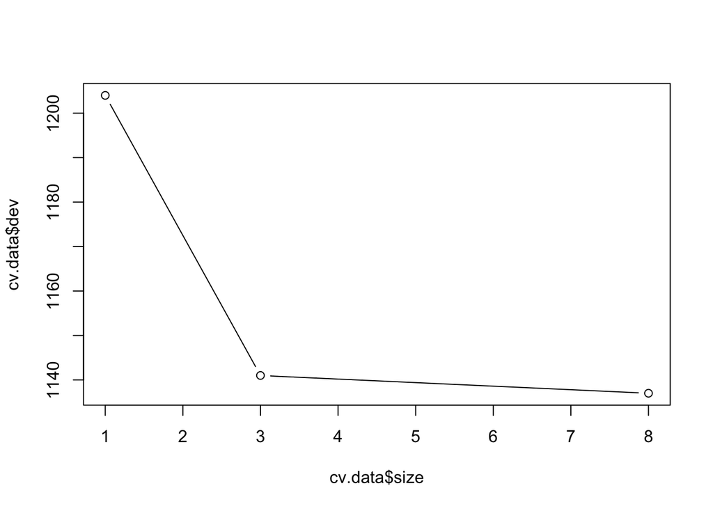

```r
# Prune tree
cv.data <- cv.tree(tree.data, FUN = prune.misclass)
plot(cv.data$size, cv.data$dev, type = 'b')
```

```r
# Analyze pruned results
prune.data = prune.tree(tree.data, best = 5)
preds <- predict(tree.data, newdata = data.test, type = "class")
sum(preds != data.test$y)/length(preds)
```

```
## [1] 0.1099372
```

```r
# 20k Training Size
set.seed(1)
train <- sample(1:nrow(data), size = 20000)
data.train <- data[train,]
data.test <- data[-train,]

# Create initial tree
tree.data <- tree(factor(y)~., data.train)

# Analyze test error
preds <- predict(tree.data, newdata = data.test, type = "class")
conf.mat <- table(preds, data.test$y)
conf.mat
```

```
##
## preds    no   yes
##   no  21109  1473
##   yes  1203  1426
```

```r
sum(preds != data.test$y)/length(preds)
```

```
## [1] 0.1061441
```

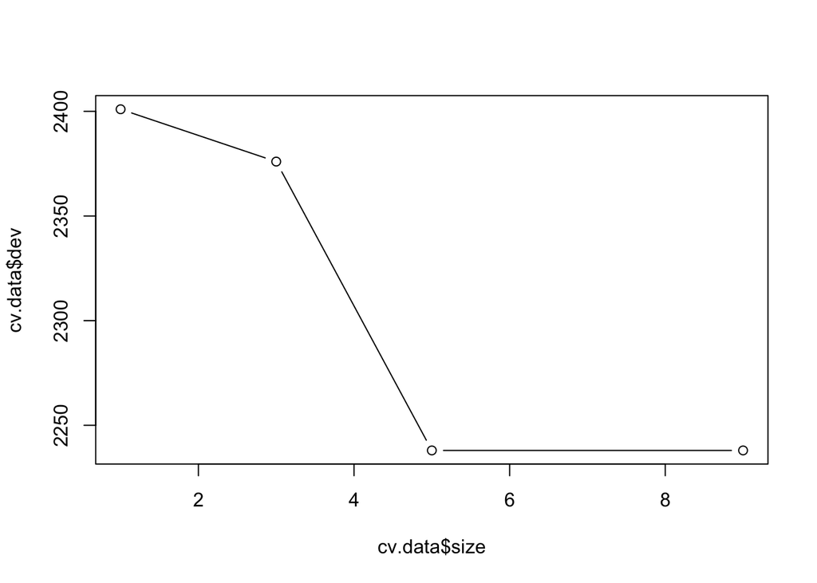

```r
# Prune tree
cv.data <- cv.tree(tree.data, FUN = prune.misclass)
plot(cv.data$size, cv.data$dev, type = 'b')
```

```r
# Analyze pruned results
prune.data = prune.tree(tree.data, best = 5)
preds <- predict(tree.data, newdata = data.test, type = "class")
sum(preds != data.test$y)/length(preds)
```

```
## [1] 0.1061441
```

```r
# 30k Training Size
set.seed(1)
train <- sample(1:nrow(data), size = 30000)
data.train <- data[train,]
data.test <- data[-train,]

# Create initial tree
tree.data <- tree(factor(y)~., data.train)

# Analyze test error
preds <- predict(tree.data, newdata = data.test, type = "class")
conf.mat <- table(preds, data.test$y)
conf.mat
```

```
##
## preds    no   yes
##   no  12774   946
##   yes   695   796
```

```r
sum(preds != data.test$y)/length(preds)
```

```
## [1] 0.1078825
```

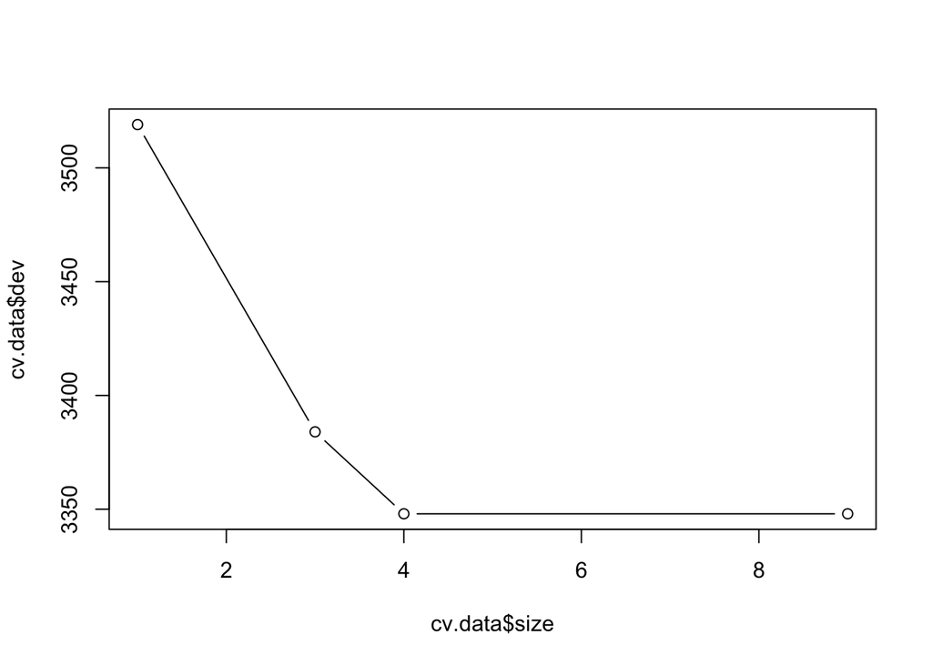

```r
# Prune tree
cv.data <- cv.tree(tree.data, FUN = prune.misclass)
plot(cv.data$size, cv.data$dev, type = 'b')
```

```r
# Analyze pruned results
prune.data = prune.tree(tree.data, best = 4)
preds <- predict(tree.data, newdata = data.test, type = "class")
sum(preds != data.test$y)/length(preds)
```

```
## [1] 0.1078825
```

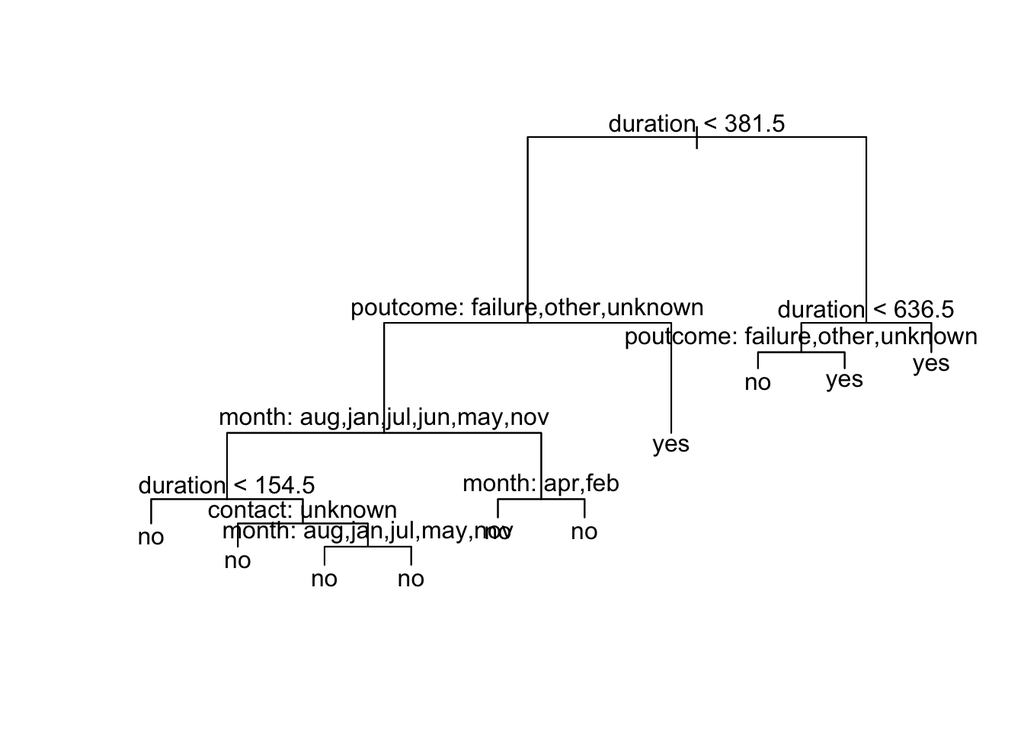

```r
# 40k Training Size
set.seed(1)
train <- sample(1:nrow(data), size = 40000)
data.train <- data[train,]
data.test <- data[-train,]

# Create and plot initial tree, since this ends up our best tree
tree.data <- tree(factor(y)~., data.train)
plot(tree.data)
text(tree.data, pretty = 0)
```

```r
# Analyze test error
preds <- predict(tree.data, newdata = data.test, type = "class")
conf.mat <- table(preds, data.test$y)
conf.mat
```

```
##
## preds   no  yes
##   no  4359  293
##   yes  245  314
```

```r
sum(preds != data.test$y)/length(preds)
```

```
## [1] 0.1032431
```

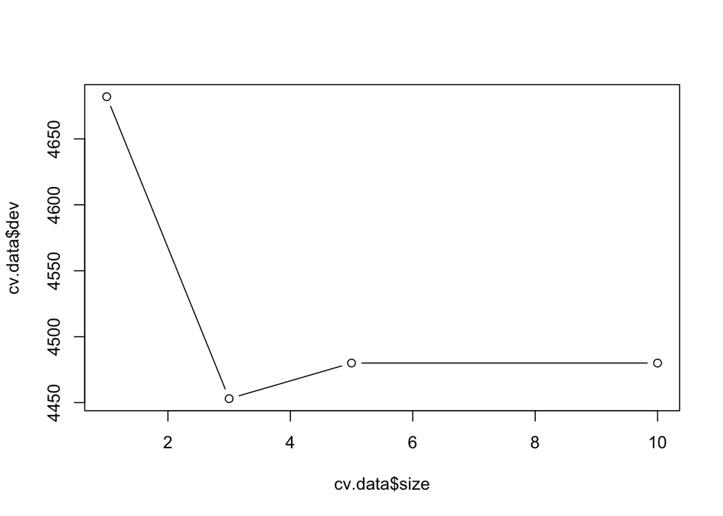

```r
# Prune tree
cv.data <- cv.tree(tree.data, FUN = prune.misclass)
plot(cv.data$size, cv.data$dev, type = 'b')
```

```r
# Analyze pruned results
prune.data = prune.tree(tree.data, best = 3)
preds <- predict(tree.data, newdata = data.test, type = "class")
sum(preds != data.test$y)/length(preds)
```

```
## [1] 0.1032431
```

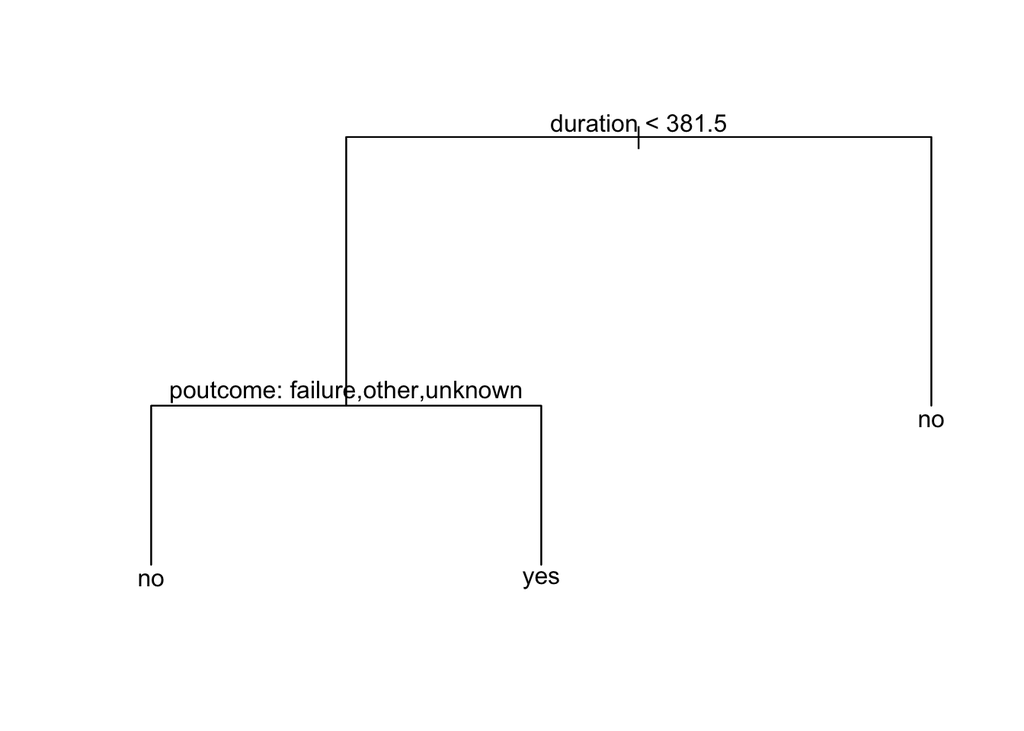

```r
plot(prune.data)
text(prune.data, pretty = 0)
```

## Boosting

```r
# 10k Training Size
data$y <- ifelse(data$y == "yes", 1, 0)

set.seed(1)
train <- sample(1:nrow(data), size = 10000)
data.train <- data[train,]
data.test <- data[-train,]


library(gbm)
```

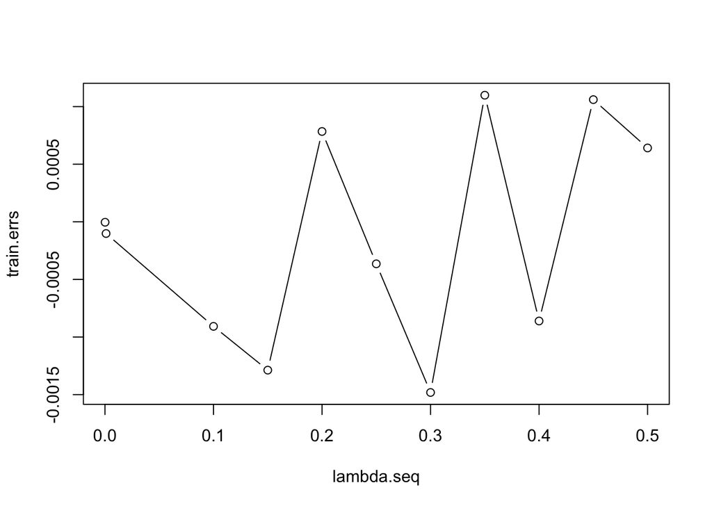

```r
lambda.seq <- c(.0001, .001, seq(from = .1, to = .5, by = .05))
train.errs <- numeric(length(lambda.seq))



for (i in 1:length(lambda.seq)) {
    boost.data <- gbm(y~., data = data.train, distribution = "bernoulli",
                         n.trees = 1000, shrinkage = lambda.seq[i])
    yhat.boost <- predict(boost.data, newdata = data.train, n.trees = 1000, type = "response")
    train.errs[i] <- mean((yhat.boost - data.train$y))
}
plot(lambda.seq, train.errs, type = "b")
```

```r
## Test error
boost.data <- gbm(y~., data = data.train, distribution = "bernoulli",
                         n.trees = 1000, shrinkage = .5)
yhat.boost <- predict(boost.data, newdata = data.test, n.trees = 1000, type = "response")

mean((yhat.boost - data.test$y))
```

```
## [1] 0.006252458
```

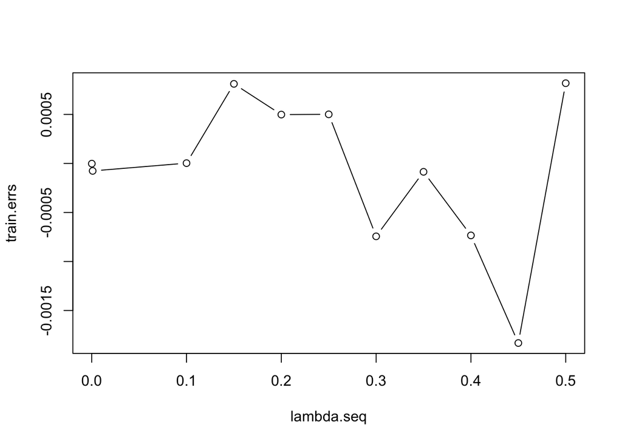

```r
# 20k Training Size
set.seed(1)
train <- sample(1:nrow(data), size = 20000)
data.train <- data[train,]
data.test <- data[-train,]


library(gbm)
lambda.seq <- c(.0001, .001, seq(from = .1, to = .5, by = .05))
train.errs <- numeric(length(lambda.seq))



for (i in 1:length(lambda.seq)) {
    boost.data <- gbm(y~., data = data.train, distribution = "bernoulli",
                         n.trees = 1000, shrinkage = lambda.seq[i])
    yhat.boost <- predict(boost.data, newdata = data.train, n.trees = 1000, type = "response")
    train.errs[i] <- mean((yhat.boost - data.train$y))
}
plot(lambda.seq, train.errs, type = "b")
```

```r
## Test error
boost.data <- gbm(y~., data = data.train, distribution = "bernoulli",
                         n.trees = 1000, shrinkage = .5)
yhat.boost <- predict(boost.data, newdata = data.test, n.trees = 1000, type = "response")

mean((yhat.boost - data.test$y))
```

```
## [1] 0.003690387
```

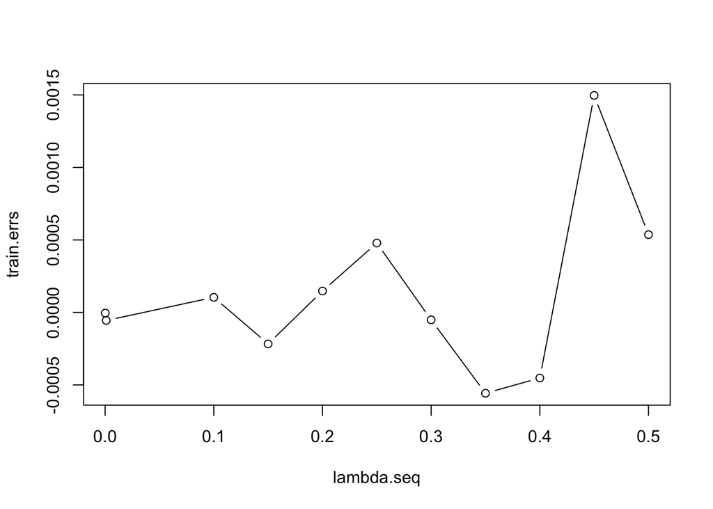

```r
# 30k Training Size
set.seed(1)
train <- sample(1:nrow(data), size = 30000)
data.train <- data[train,]
data.test <- data[-train,]


library(gbm)
lambda.seq <- c(.0001, .001, seq(from = .1, to = .5, by = .05))
train.errs <- numeric(length(lambda.seq))



for (i in 1:length(lambda.seq)) {
    boost.data <- gbm(y~., data = data.train, distribution = "bernoulli",
                         n.trees = 1000, shrinkage = lambda.seq[i])
    yhat.boost <- predict(boost.data, newdata = data.train, n.trees = 1000, type = "response")
    train.errs[i] <- mean((yhat.boost - data.train$y))
}
plot(lambda.seq, train.errs, type = "b")
```

```r
## Test error
boost.data <- gbm(y~., data = data.train, distribution = "bernoulli",
                         n.trees = 1000, shrinkage = .5)
yhat.boost <- predict(boost.data, newdata = data.test, n.trees = 1000, type = "response")

mean((yhat.boost - data.test$y))
```

```
## [1] 0.003420768
```

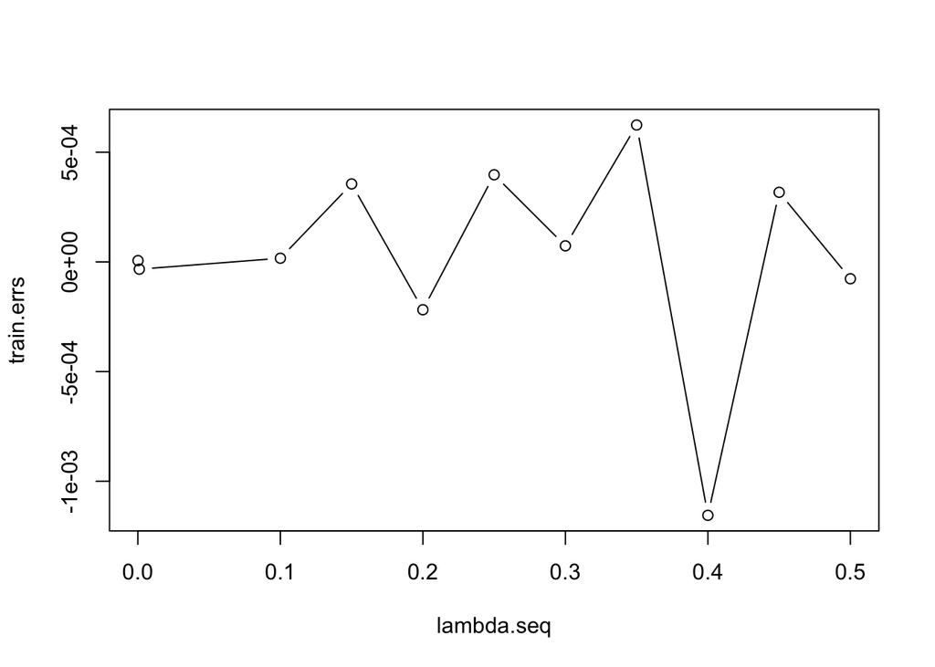

```r
# 40k Training Size
set.seed(1)
train <- sample(1:nrow(data), size = 40000)
data.train <- data[train,]
data.test <- data[-train,]


library(gbm)
lambda.seq <- c(.0001, .001, seq(from = .1, to = .5, by = .05))
train.errs <- numeric(length(lambda.seq))



for (i in 1:length(lambda.seq)) {
    boost.data <- gbm(y~., data = data.train, distribution = "bernoulli",
                         n.trees = 1000, shrinkage = lambda.seq[i])
    yhat.boost <- predict(boost.data, newdata = data.train, n.trees = 1000, type = "response")
    train.errs[i] <- mean((yhat.boost - data.train$y))
}
plot(lambda.seq, train.errs, type = "b")
```

```r
## Test error
boost.data <- gbm(y~., data = data.train, distribution = "bernoulli",
                         n.trees = 1000, shrinkage = .5)
yhat.boost <- predict(boost.data, newdata = data.test, n.trees = 1000, type = "response")

mean((yhat.boost - data.test$y))
```

```
## [1] 0.001897901
```

## Random Forest

```r
library(randomForest)
# 10k Training Size
set.seed(1)
train <- sample(1:nrow(data), size = 10000)
data.train <- data[train,]
data.test <- data[-train,]

data.rf <- randomForest(factor(y)~., data.train,
                           importance = TRUE)
## Test error
yhat.rf <- predict(data.rf, newdata = data.test)

mean((yhat.rf != data.test$y))
```

```
## [1] 0.09352191
```

```r
# 20k Training Size
set.seed(1)
train <- sample(1:nrow(data), size = 20000)
data.train <- data[train,]
data.test <- data[-train,]

data.rf <- randomForest(factor(y)~., data.train,
                           importance = TRUE)
## Test error
yhat.rf <- predict(data.rf, newdata = data.test)

mean((yhat.rf != data.test$y))
```

```
## [1] 0.09043671
```

```r
# 30k Training Size
set.seed(1)
train <- sample(1:nrow(data), size = 30000)
data.train <- data[train,]
data.test <- data[-train,]

data.rf <- randomForest(factor(y)~., data.train,
                           importance = TRUE)
## Test error
yhat.rf <- predict(data.rf, newdata = data.test)

mean((yhat.rf != data.test$y))
```

```
## [1] 0.08986917
```

```r
# 40k Training Size

set.seed(1)
train <- sample(1:nrow(data), size = 40000)
data.train <- data[train,]
data.test <- data[-train,]

data.rf <- randomForest(factor(y)~., data.train,
                           importance = TRUE)
## Test error
yhat.rf <- predict(data.rf, newdata = data.test)
mean((yhat.rf != data.test$y))
```

```
## [1] 0.0880829
```

## Bagging

```r
# 10k Training Size

set.seed(1)
train <- sample(1:nrow(data), size = 10000)
data.train <- data[train,]
data.test <- data[-train,]

bag.data <- randomForest(factor(y)~., data = data.train, mtry = 16, importance = TRUE)
## Test error
yhat.bag <- predict(bag.data, newdata = data.test)
mean(yhat.bag != data.test$y)
```

```
## [1] 0.09627673
```

```r
# 20k Training Size

set.seed(1)
train <- sample(1:nrow(data), size = 20000)
data.train <- data[train,]
data.test <- data[-train,]

bag.data <- randomForest(factor(y)~., data = data.train, mtry = 16, importance = TRUE)
## Test error
yhat.bag <- predict(bag.data, newdata = data.test)
mean(yhat.bag != data.test$y)
```

```
## [1] 0.09162667
```

```r
# 30k Training Size

set.seed(1)
train <- sample(1:nrow(data), size = 30000)
data.train <- data[train,]
data.test <- data[-train,]

bag.data <- randomForest(factor(y)~., data = data.train, mtry = 16, importance = TRUE)
## Test error
yhat.bag <- predict(bag.data, newdata = data.test)
mean(yhat.bag != data.test$y)
```

```
## [1] 0.0921044
```

```r
# 40k Training Size

set.seed(1)
train <- sample(1:nrow(data), size = 40000)
data.train <- data[train,]
data.test <- data[-train,]

bag.data <- randomForest(factor(y)~., data = data.train, mtry = 16, importance = TRUE)

## Test error
yhat.bag <- predict(bag.data, newdata = data.test)
mean(yhat.bag != data.test$y)
```

```
## [1] 0.09000192
```

## Neural Networks

```r
library(nnet)

# 10k Training Size

set.seed(1)
train <- sample(1:nrow(data), size = 10000)
data.train <- data[train,]
data.test <- data[-train,]

nnet.data <- nnet(factor(y)~., data = data, subset = train, linout = FALSE, size=20)
## Test error
yhat.nnet <- predict(nnet.data, newdata = data.test, type = "class")
mean(yhat.nnet != data.test$y)
```

```
## [1] 0.1157309
```

```r
# 20k Training Size

set.seed(1)
train <- sample(1:nrow(data), size = 20000)
data.train <- data[train,]
data.test <- data[-train,]

nnet.data <- nnet(factor(y)~., data = data, subset = train, linout = FALSE, size=20)
## Test error
yhat.nnet <- predict(nnet.data, newdata = data.test, type = "class")
mean(yhat.nnet != data.test$y)
```

```
## [1] 0.1150688
```

```r
# 30k Training Size

set.seed(1)
train <- sample(1:nrow(data), size = 30000)
data.train <- data[train,]
data.test <- data[-train,]

nnet.data <- nnet(factor(y)~., data = data, subset = train, linout = FALSE, size=20)
## Test error
yhat.nnet <- predict(nnet.data, newdata = data.test, type = "class")
mean(yhat.nnet != data.test$y)
```

```
## [1] 0.1135363
```

```r
# 40k Training Size

set.seed(1)
train <- sample(1:nrow(data), size = 40000)
data.train <- data[train,]
data.test <- data[-train,]

nnet.data <- nnet(factor(y)~., data = data, subset = train, linout = FALSE, size=20)
## Test error
yhat.nnet <- predict(nnet.data, newdata = data.test, type = "class")
mean(yhat.nnet != data.test$y)
```

```
## [1] 0.1162925
```

## Support Vector Machines

```r
library(e1071)

# 10k Training Size

set.seed(1)
train <- sample(1:nrow(data), size = 10000)
data.train <- data[train,]
data.test <- data[-train,]

tune.out <- tune(svm, factor(y)~., data = data.train, kernel = "polynomial",
                 ranges = list(cost = c(.01, .1, .5, 1, 5, 10)))
summary(tune.out)
```

```
##
## Parameter tuning of 'svm':
##
## - sampling method: 10-fold cross validation
##
## - best parameters:
##  cost
##    10
##
## - best performance: 0.1128
##
## - Detailed performance results:
##    cost  error  dispersion
## 1  0.01 0.1205 0.009478045
## 2  0.10 0.1202 0.009953224
## 3  0.50 0.1192 0.009874771
## 4  1.00 0.1186 0.010068653
## 5  5.00 0.1150 0.010561986
## 6 10.00 0.1128 0.010075272
```

```r
svcfit <- svm(factor(y)~., data = data.train, kernel = "polynomial",
              cost = 10)

## Test error
train.preds <- predict(svcfit, data.train)
mean(train.preds != data.train$y)
```

```
## [1] 0.1023
```

```r
# 20k Training Size

set.seed(1)
train <- sample(1:nrow(data), size = 20000)
data.train <- data[train,]
data.test <- data[-train,]

tune.out <- tune(svm, factor(y)~., data = data.train, kernel = "polynomial",
                 ranges = list(cost = c(.01, .1, .5, 1, 5, 10)))
summary(tune.out)
```

```
##
## Parameter tuning of 'svm':
##
## - sampling method: 10-fold cross validation
##
## - best parameters:
##  cost
##    10
##
## - best performance: 0.1092
##
## - Detailed performance results:
##    cost   error  dispersion
## 1  0.01 0.11960 0.006732178
## 2  0.10 0.11975 0.006558497
## 3  0.50 0.11890 0.006694940
## 4  1.00 0.11775 0.006925196
## 5  5.00 0.11245 0.006152913
## 6 10.00 0.10920 0.005769652
```

```r
svcfit <- svm(factor(y)~., data = data.train, kernel = "polynomial",
              cost = .5)

## Test error
train.preds <- predict(svcfit, data.train)
mean(train.preds != data.train$y)
```

```
## [1] 0.11745
```

```r
# 30k Training Size

set.seed(1)
train <- sample(1:nrow(data), size = 30000)
data.train <- data[train,]
data.test <- data[-train,]

tune.out <- tune(svm, factor(y)~., data = data.train, kernel = "polynomial",
                 ranges = list(cost = c(.01, .1, .5, 1, 5, 10)))
summary(tune.out)
```

```
##
## Parameter tuning of 'svm':
##
## - sampling method: 10-fold cross validation
##
## - best parameters:
##  cost
##    10
##
## - best performance: 0.1053667
##
## - Detailed performance results:
##    cost     error  dispersion
## 1  0.01 0.1183000 0.005339002
## 2  0.10 0.1183000 0.005219739
## 3  0.50 0.1168333 0.005340851
## 4  1.00 0.1152000 0.005427866
## 5  5.00 0.1091667 0.005268706
## 6 10.00 0.1053667 0.004905150
```

```r
svcfit <- svm(factor(y)~., data = data.train, kernel = "polynomial",
              cost = .5)

## Test error
train.preds <- predict(svcfit, data.train)
mean(train.preds != data.train$y)
```

```
## [1] 0.1158333
```

```r
# 40k Training Size

set.seed(1)
train <- sample(1:nrow(data), size = 40000)
data.train <- data[train,]
data.test <- data[-train,]

tune.out <- tune(svm, factor(y)~., data = data.train, kernel = "polynomial",
                 ranges = list(cost = c(.01, .1, .5, 1, 5, 10)))
summary(tune.out)
```

```
##
## Parameter tuning of 'svm':
##
## - sampling method: 10-fold cross validation
##
## - best parameters:
##  cost
##    10
##
## - best performance: 0.102575
##
## - Detailed performance results:
##    cost    error  dispersion
## 1  0.01 0.117175 0.004784306
## 2  0.10 0.117175 0.004663764
## 3  0.50 0.115300 0.003902990
## 4  1.00 0.112700 0.004212745
## 5  5.00 0.105850 0.004062361
## 6 10.00 0.102575 0.004190018
```

```r
svcfit <- svm(factor(y)~., data = data.train, kernel = "polynomial",
              cost = .5)

## Test error
train.preds <- predict(svcfit, data.train)
mean(train.preds != data.train$y)
```

```
## [1] 0.113675
```

# Conclusion

[output not shown]